# ECS530: (preVIII) Spatial econometrics

Roger Bivand

Thursday 12 November 2020, 12:30-13.30

### Copyright

All the material presented here, to the extent it is original, is available under [CC-BY-SA](https://creativecommons.org/licenses/by-sa/4.0/). Parts build on joint tutorials with Edzer Pebesma.

### Required current contributed CRAN packages:

I am running R 4.0.3, with recent `update.packages()`.

```r
needed <- c("sphet", "spatialreg", "spdep", "spData", "sf", "HSAR", "sp")
```

### Script

Script and data at https://github.com/rsbivand/ECS530_h20/raw/main/ECS530_preVIII.zip. Download to suitable location, unzip and use as basis.

### Schedule

- 9/11 (I) Spatial data representation, (II) Support+topology, input/output
- 10/11 (III) Coordinate reference systems, (IV) Visualization
- 11/11 (VI) Spatial autocorrelation, *project surgery*
- 12/11 (VII) Spatial regression, **(preVIII) Spatial econometrics**, (VIII) Spatial multilevel regression
- 13/11 (IX) Interpolation, point processes, *project surgery*, *presentation*
- 14/11 *Presentations*

## Session VIII

- 12:30-13:30 Spatial econometrics

### Spatial econometrics software in R: environment

- Beyond software functionality, the existence of communities of interest becomes important
- These extend the choices available, and bring in points of view across applied scientific domains and in modern computation, for example interworking across C++, Python and Julia with R
- For example, the **HSAR** package [G. Dong and Harris (2015); dongetal:15] uses C++ extensively, rather than R sparse matrix packages
- The model being introduced into **INLA** for non-MCMC Bayesian inference is another example of cooperation with other applied statisticians
- The R packages **spatialreg**, **sphet** (Bivand and Piras 2015) and for spatial panel models **splm** (Millo and Piras 2012) provide implementations of many model fitting functions for Gaussian dependent variables
- These also use shared methods in **spdep** for computing impacts, and for MC inference on impacts
- There are a range of fitting functions for non-Gaussian dependent variables in **McSpatial**, **spatialprobit** (Wilhelm and Matos 2013) and **ProbitSpatial**, and these are also available using the ´slm´ model being introduced into **INLA**
- Work is continuing on providing Bayesian inference functions, through MCMC and otherwise; the **HSAR** package is an example

### Beijing leased residential land parcels data set (2003-2009)

The Beijing leased residential land parcels data set has been made available in the **HSAR** package. There are 1117 observed land parcels, grouped into 111 districts. The data are for most of the districts for which parcel price data was available for the 2003-2009 period; some isolated districs were also excluded.

```r
library(sp)
library(HSAR)
data(landprice)
data(landSPDF)
```

The parcel data as provided are in two objects, a `data.frame` and a `SpatialPointsDataFrame`, which need to be merged and ordered by district ID (obs relate to the original parcel IDs):

```r
library(sf)
landprice1 <- st_as_sf(landSPDF)
landprice1 <- merge(landprice1, landprice, by="obs")
landprice2 <- landprice1[order(landprice1$district.id.x),]
```

Categorical variables, such as the year relating to the price, and the district ID, should be specified as `factor` objects, to permit the creation of dummies on-the-fly:

```r
landprice2$fyear <- factor(landprice2$year + 2003)
landprice2$f_district.id.x <- factor(landprice2$district.id.x)
```

Because `formula` objects can include simple functions, such as `log` of variables, we revert pre-computed logs:

```r
landprice2$price <- exp(landprice2$lnprice)
landprice2$area <- exp(landprice2$lnarea)
landprice2$Dcbd <- exp(landprice2$lndcbd)
landprice2$Dsubway <- exp(landprice2$dsubway)
landprice2$Dpark <- exp(landprice2$dpark)
landprice2$Dele <- exp(landprice2$dele)
```

### Parcel-level spatial weights

We use the weights specified in (R. A. J. Dong Guanpeng AND Harris 2015), an exponential decay function with a distance threshold of 1.5km; they are stored in a sparse `listw` object. We need to set `zero.policy` because seven parcels have no neighbours at this threshold:

```r
suppressPackageStartupMessages(library(spdep))
dnb1.5 <- dnearneigh(landprice2, 0, 1500, row.names=row.names(landprice2))
dists <- nbdists(dnb1.5, st_coordinates(landprice2))
edists <- lapply(dists, function(x) exp((-((x/1000)^2))/(1.5^2)))
ozpo <- set.ZeroPolicyOption(TRUE)
lw <- nb2listw(dnb1.5, glist=edists, style="W")
library(spatialreg)
W <- as(lw, "CsparseMatrix")
trs <- trW(W, m=50)
```

### Formula objects

For over twenty years, `data.frame` and `formula` objects have defined S and R syntax. Use of update methods allows flexibility and re-use; the `data=` argument points to the object containing the named variables (columns):

```r
form <- log(price) ~ log(area) + log(Dcbd) + log(Dele) + log(Dpark) + log(Dsubway) +
  crimerate + popden + fyear
OLS <- lm(form, data=landprice2)
```

### Using fitted model objects

There are many standard methods for fitted model objects, especially `print` and `summary` methods, which are not shown here. Let’s use Moran’s $I$ to test for residual spatial autocorrelation (and/or other mis-specifications):

```r
lm.morantest(OLS, lw)
```

```
##
##  Global Moran I for regression residuals
##
## data:
## model: lm(formula = form, data = landprice2)
## weights: lw
##
## Moran I statistic standard deviate = 15.1, p-value < 2.2e-16
## alternative hypothesis: greater
## sample estimates:
## Observed Moran I      Expectation         Variance
##     0.1944768641    -0.0054494313     0.0001753028
```

### Same framework with spatial models

It makes sense to use the formula/data framework for functions fitting spatial econometrics models, such as SLX; we need a spatial weights `listw` object, qualified by accepting parcels without neighbours:

```r
SLX <- lmSLX(form, data=landprice2, listw=lw, zero.policy=TRUE)
```

### SLX residual autocorrelation

The fitted object still inherits from `lm`, so functions and methods expecting such an object will still work. There is still a lot of spatial autocorrelation in the residuals:

```r
class(SLX)
```

```
## [1] "SLX" "lm"
```

```r
lm.morantest(SLX, lw)
```

```
##
##  Global Moran I for regression residuals
##
## data:
## model: lm(formula = formula(paste("y ~ ", paste(colnames(x)[-1],
## collapse = "+"))), data = as.data.frame(x), weights = weights)
## weights: lw
##
## Moran I statistic standard deviate = 14.294, p-value < 2.2e-16
## alternative hypothesis: greater
## sample estimates:
## Observed Moran I      Expectation         Variance
##     0.1768367391    -0.0095750057     0.0001700666
```

### Impacts: local and global

The SLX model has come into focus recently because of its ease of estimation, and because the coefficients may be treated as direct and indirect impacts, with total impacts calculated by linear combination:

```r
imps_SLX <- impacts(SLX)
imps_SLX
```

```
## Impact measures (SLX, estimable):
##                    Direct     Indirect        Total
## log(area)    -0.027393865  0.090812258  0.063418393
## log(Dcbd)    -0.586485128  0.362485133 -0.223999995
## log(Dele)     0.017324132 -0.159256358 -0.141932226
## log(Dpark)   -0.091259953 -0.212539298 -0.303799251
## log(Dsubway) -0.176849400 -0.146595779 -0.323445180
## crimerate     0.003700684  0.006267203  0.009967887
## popden        0.003018936  0.038261481  0.041280417
## fyear2004    -0.203603540  0.448210479  0.244606939
## fyear2005    -0.037845735  0.874443554  0.836597820
## fyear2006    -0.117303538  0.212143967  0.094840429
## fyear2007     0.689975245 -0.246715186  0.443260059
## fyear2008     0.465854623 -0.266940282  0.198914342
## fyear2009     2.203749162  0.406971450  2.610720612
```

### Maximum likelihood — error model

The spatial error model (SEM) may be estimated by maximum likelihood (case weights may also be used), here using eigenvalues of the spatial weights to compute the Jacobian (Bivand, Hauke, and Kossowski 2013). The Hausman test (Pace and LeSage 2008) examines whether the SEM coefficients differ from OLS coefficients:

```r
e <- eigenw(lw)
int <- 1/range(e)
SEM <- errorsarlm(form, data=landprice2, listw=lw, interval=int, control=list(pre_eig=e), zero.policy=TRUE)
Hausman.test(SEM)
```

```
##
##  Spatial Hausman test (asymptotic)
##
## data:  NULL
## Hausman test = 24.24, df = 14, p-value = 0.04285
```

### GMM estimation of SEM

The **sphet** package (Piras 2010) provides a wide range of model fitting options, terming the spatial coefficient on the error $\rho$, rather than $\lambda$, and the other way round for the lag coefficient on the dependent variable:

```r
library(sphet)
ozpo <- set.ZeroPolicyOption(TRUE)
GM_SEM <- spreg(form, data=landprice2, listw=lw, model="error")
```

### ML Durbin SEM

The spatial Durbin error model (SDEM), like SLX, adds the spatially lagged independent variables on the right hand side, and may be estimated by maximum likelihood:

```r
SDEM <- errorsarlm(form, data=landprice2, listw=lw, etype="emixed",
 interval=int, control=list(pre_eig=e), zero.policy=TRUE)
Hausman.test(SDEM)
```

```
##
##  Spatial Hausman test (asymptotic)
##
## data:  NULL
## Hausman test = 12.872, df = 27, p-value = 0.99
```

### SDEM impacts

SDEM impacts, like those for SLX, are calculated by linear combination:

```r
imps_SDEM <- spatialreg::impacts(SDEM)
imps_SDEM
```

```
## Impact measures (SDEM, estimable):
##                    Direct      Indirect        Total
## log(area)    -0.025312192  0.0899318945  0.064619702
## log(Dcbd)    -0.588066018  0.3297094494 -0.258356569
## log(Dele)    -0.002311491 -0.1215961308 -0.123907622
## log(Dpark)   -0.081889383 -0.2187482979 -0.300637681
## log(Dsubway) -0.168100998 -0.1136152579 -0.281716256
## crimerate     0.006368131 -0.0007289118  0.005639219
## popden        0.004766271  0.0394667815  0.044233052
## fyear2004    -0.206852031  0.2244677181  0.017615687
## fyear2005    -0.047901500  0.5532040754  0.505302575
## fyear2006    -0.132401030  0.0290397225 -0.103361308
## fyear2007     0.693289819 -0.4672462567  0.226043562
## fyear2008     0.485618722 -0.1354646846  0.350154038
## fyear2009     2.299169404  0.7608231609  3.059992565
```

### Maximum likelihood spatial lag model

The spatial lag model (SAR) is estimated using by maximum likelihood. There is also an LM test for residual autocorrelation:

```r
SAR <- lagsarlm(form, data=landprice2, listw=lw, type="lag", interval=int, control=list(pre_eig=e), zero.policy=TRUE)
digits <- max(5, .Options$digits - 3)
cat("test value: ", format(signif(SAR$LMtest, digits)), ", p-value: ",
 format.pval((1 - pchisq(SAR$LMtest, 1)), digits), "\n", sep="")
```

```
## test value: 58.514, p-value: 2.0206e-14
```

### SAR impacts

The impacts method for SAR (and SDM) fitted model objects uses simple samples from the multivariate distribution of the coefficients and their covariances for inferences, and uses traces of powers of the spatial weights:

```r
spatialreg::impacts(SAR, tr=trs)
```

```
## Impact measures (lag, trace):
##                    Direct     Indirect        Total
## log(area)    -0.005066435 -0.002046688 -0.007113123
## log(Dcbd)    -0.167881960 -0.067819272 -0.235701232
## log(Dele)    -0.048279743 -0.019503567 -0.067783310
## log(Dpark)   -0.211249350 -0.085338395 -0.296587745
## log(Dsubway) -0.173562177 -0.070113909 -0.243676085
## crimerate     0.004947226  0.001998531  0.006945756
## popden        0.024700110  0.009978103  0.034678213
## fyear2004    -0.186140380 -0.075195125 -0.261335505
## fyear2005    -0.027768036 -0.011217453 -0.038985489
## fyear2006    -0.088974266 -0.035942933 -0.124917199
## fyear2007     0.540520655  0.218354118  0.758874773
## fyear2008     0.400969047  0.161979458  0.562948504
## fyear2009     2.266803638  0.915720619  3.182524258
```

### GMM estimation of SAR

The **sphet** package (Piras 2010) provides a number of ways of fitting this model, calling the coefficient $\lambda$:

```r
library(sphet)
GM_SAR <- spreg(form, data=landprice2, listw=lw, model="lag")
```

### GMM SAR impacts

Also works, but we need to chase up interface issues between **sphet** and **spdep**:

```r
m <- nrow(GM_SAR$coefficients)
GM_SAR$coefficients <- drop(GM_SAR$coefficients)
GM_SAR$coefficients <- GM_SAR$coefficients[c(m, (1:(m-1)))]
GM_SAR$var <- GM_SAR$var[c(m, (1:(m-1))), c(m, (1:(m-1)))]
# impacts(GM_SAR, tr=trs)
```

### Spatial lag Durbin model

As with the SLX and SDEM models, the lags of the independent variables are made automatically (this needs revisiting for SLX and SDEM to permit different and possibly multiple matrices to be used):

```r
SDM <- lagsarlm(form, data=landprice2, listw=lw, type="mixed", interval=int, control=list(pre_eig=e), zero.policy=TRUE)
digits <- max(5, .Options$digits - 3)
cat("test value: ", format(signif(SDM$LMtest, digits)), ", p-value: ",
 format.pval((1 - pchisq(SDM$LMtest, 1)), digits), "\n", sep="")
```

```
## test value: 0.17127, p-value: 0.67898
```

### Tests between SLX, SDM and SDEM

We can use Likelihood ratio tests between nesting models

```r
cat(capture.output(LR.sarlm(SAR, SDM))[c(7,8,5)], sep="\n")
```

```
## Log likelihood of SAR Log likelihood of SDM
##             -1334.149             -1296.823
## Likelihood ratio = -74.652, df = 13, p-value = 1.105e-10
```

```r
cat(capture.output(LR.sarlm(SEM, SDM))[c(7,8,5)], sep="\n")
```

```
## Log likelihood of SEM Log likelihood of SDM
##             -1309.654             -1296.823
## Likelihood ratio = -25.661, df = 13, p-value = 0.01887
```

```r
cat(capture.output(LR.sarlm(SEM, SDEM))[c(7,8,5)], sep="\n")
```

```
##  Log likelihood of SEM Log likelihood of SDEM
##              -1309.654              -1296.305
## Likelihood ratio = -26.697, df = 13, p-value = 0.01369
```

### Tests between SLX, SDM and SDEM

```r
cat(capture.output(LR.sarlm(SLX, SDM))[c(7,8,5)], sep="\n")
```

```
## Log likelihood of SLX Log likelihood of SDM
##             -1349.730             -1296.823
## Likelihood ratio = -105.81, df = 1, p-value < 2.2e-16
```

```r
cat(capture.output(LR.sarlm(SLX, SDEM))[c(7,8,5)], sep="\n")
```

```
##  Log likelihood of SLX Log likelihood of SDEM
##              -1349.730              -1296.305
## Likelihood ratio = -106.85, df = 1, p-value < 2.2e-16
```

### SDM impacts

Here we’ll take samples to use later:

```r
set.seed(1)
imps <- spatialreg::impacts(SDM, tr=trs, R=2000)
imps
```

```
## Impact measures (mixed, trace):
##                    Direct     Indirect        Total
## log(area)    -0.023812364  0.113019489  0.089207125
## log(Dcbd)    -0.025324844 -0.252607004 -0.277931848
## log(Dele)     0.015649846 -0.158102250 -0.142452404
## log(Dpark)   -0.023813315 -0.298648573 -0.322461888
## log(Dsubway) -0.154160382 -0.156320343 -0.310480725
## crimerate     0.005102878  0.002823557  0.007926435
## popden        0.005447242  0.044886407  0.050333649
## fyear2004    -0.200503511  0.424641128  0.224137618
## fyear2005    -0.040082358  0.882319752  0.842237393
## fyear2006    -0.121239177  0.222404995  0.101165817
## fyear2007     0.708046770 -0.306736303  0.401310467
## fyear2008     0.460894440 -0.268754916  0.192139524
## fyear2009     2.266709634  1.070861985  3.337571619
```

### Impacts by simple linear algebra

Let’s also explore the impacts of the log(area) variable the manual way; the direct impact is the same, the total differs very slightly:

```r
IrW1 <- invIrW(lw, rho=coef(SDM)[1])
n <- nrow(landprice2)
S_area <- IrW1 %*% ((diag(n) * coef(SDM)[3]) + (coef(SDM)[16] * W))
sum(S_area)/n
```

```
## [1] 0.08847212
```

```r
sum(diag(S_area))/n
```

```
## [1] -0.02381236
```

### Total impacts by incremented prediction

If we make a prediction (using GSoC 2015 code by Martin Gubri based on (Thomas-Agnan, Laurent, and Goulard 2014)) from the fitted model, increment area, and make a new prediction, the mean difference is the total impact:

```r
newdata <- landprice2
suppressWarnings(p0 <- predict(SDM, newdata=newdata, listw=lw))
newdata$area <- exp(log(newdata$area)+1)
suppressWarnings(p1 <- predict(SDM, newdata=newdata, listw=lw))
mean(p1-p0)
```

```
## [1] 0.08847212
```

### MCMC spatial Durbin fitting

Following GSoC 2011, parts of the Spatial Econometrics toolbox were translated into R, with default 2500 draws and 500 omitted as burnin:

```r
set.seed(1)
BSDM <- spBreg_lag(form, data=landprice2, listw=lw, type="Durbin")
```

## #MCMC impacts

As we already have the draws, we do not need to sample again to be able to infer:

```r
impsB <- spatialreg::impacts(BSDM, tr=trs)
impsB
```

```
## Impact measures (mixed, trace):
##                    Direct     Indirect        Total
## log(area)    -0.023152974  0.113307132  0.090154158
## log(Dcbd)    -0.032380034 -0.246041656 -0.278421690
## log(Dele)     0.015984059 -0.158467681 -0.142483622
## log(Dpark)   -0.024342363 -0.300567009 -0.324909372
## log(Dsubway) -0.152068596 -0.155639100 -0.307707697
## crimerate     0.005035336  0.002922671  0.007958007
## popden        0.005458656  0.044656804  0.050115460
## fyear2004    -0.200777988  0.425261787  0.224483799
## fyear2005    -0.038432141  0.897514140  0.859081998
## fyear2006    -0.122970442  0.228386762  0.105416320
## fyear2007     0.706575015 -0.303635058  0.402939957
## fyear2008     0.466039811 -0.284447551  0.181592260
## fyear2009     2.265015077  1.070339228  3.335354305
```

### Total impact of log(area)

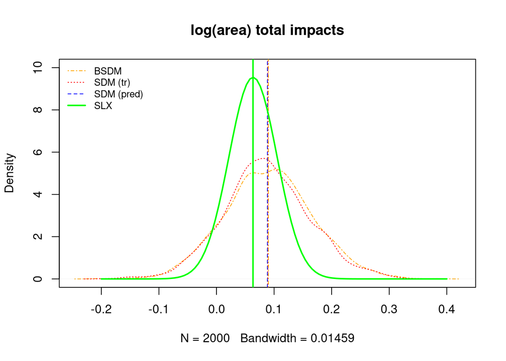

```r
plot(density(impsB$sres$total[,1]), lty=4, col="orange", main="log(area) total impacts", ylim=c(0, 10))
lines(density(imps$sres$total[,1]), lty=3, col="red")
abline(v=imps$res$total[1], lty=3, col="red")
abline(v=impsB$res$total[1], lty=4, col="orange")
abline(v=mean(p1-p0), lty=2, col="blue")
abline(v=imps_SLX$impacts$total[1], lwd=2, col="green")
curve(dnorm(x, mean=imps_SLX$impacts$total[1], sd=imps_SLX$se$total[1]), col="green", lwd=2, add=TRUE, from=-0.2, to=0.4)
legend("topleft", legend=c("BSDM", "SDM (tr)", "SDM (pred)", "SLX"), lty=c(4,3,2,1), col=c("orange", "red", "blue", "green"), lwd=c(1,1,1,2), bty="n", cex=0.8)
```

Here we show the sampled distributions from the fitted ML model, the MCMC total impacts (red and orange dotted lines), the blue point total impact from prediction difference, and the point estimate and implied distrubution from the SLX model (in green).

### General Nested Model (GNM)

The GNM is a SAC (both lag and error coefficients, aka SARAR) with spatially lagged independent variables. It suffers from the same problems as all SARAR - a tendency for the two coefficients to flip

```r
GNM <- sacsarlm(form, data=landprice2, listw=lw, type="sacmixed", interval1=int, interval2=int,
 control=list(pre_eig1=e, pre_eig2=e), zero.policy=TRUE)
```

### Impacts

SAC and GNS fitted models also need impacts computed:

```r
spatialreg::impacts(GNM, tr=trs)
```

```
## Impact measures (sacmixed, trace):
##                    Direct      Indirect        Total
## log(area)    -0.024993063  0.0926036289  0.067610566
## log(Dcbd)    -0.500457644  0.2378651652 -0.262592479
## log(Dele)    -0.001220104 -0.1261306225 -0.127350726
## log(Dpark)   -0.071096460 -0.2332392492 -0.304335709
## log(Dsubway) -0.166025683 -0.1191637251 -0.285189408
## crimerate     0.006327946 -0.0002760188  0.006051927
## popden        0.004718665  0.0403153345  0.045034000
## fyear2004    -0.204446287  0.2477368775  0.043290590
## fyear2005    -0.044550665  0.5929889181  0.548438253
## fyear2006    -0.130205529  0.0431112527 -0.087094276
## fyear2007     0.697252303 -0.4543278450  0.242924458
## fyear2008     0.482625151 -0.1600300739  0.322595077
## fyear2009     2.293721029  0.8036967234  3.097417752
```

### Tests between GNM, SDM and SDEM

```r
cat(capture.output(LR.sarlm(SDM, GNM))[c(7,8,5)], sep="\n")
```

```
## Log likelihood of SDM Log likelihood of GNM
##             -1296.823             -1296.248
## Likelihood ratio = -1.1504, df = 1, p-value = 0.2835
```

```r
cat(capture.output(LR.sarlm(SDEM, GNM))[c(7,8,5)], sep="\n")
```

```
## Log likelihood of SDEM  Log likelihood of GNM
##              -1296.305              -1296.248
## Likelihood ratio = -0.1148, df = 1, p-value = 0.7347
```

Bivand, Roger, and Gianfranco Piras. 2015. “Comparing Implementations of Estimation Methods for Spatial Econometrics.” *Journal of Statistical Software* 63 (1): 1–36. https://doi.org/10.18637/jss.v063.i18.

Bivand, Roger S., Jan Hauke, and Tomasz Kossowski. 2013. “Computing the Jacobian in Gaussian Spatial Autoregressive Models: An Illustrated Comparison of Available Methods.” *Geographical Analysis* 45 (2): 150–79.

Dong, Guanpeng, and Richard Harris. 2015. “Spatial Autoregressive Models for Geographically Hierarchical Data Structures.” *Geographical Analysis* 47 (2): 173–91. https://doi.org/10.1111/gean.12049.

Dong, Richard AND Jones, Guanpeng AND Harris. 2015. “Multilevel Modelling with Spatial Interaction Effects with Application to an Emerging Land Market in Beijing, China.” *PLoS ONE* 10 (6): 1–18. https://doi.org/10.1371/journal.pone.0130761.

Millo, Giovanni, and Gianfranco Piras. 2012. “Splm: Spatial Panel Data Models in.” *Journal of Statistical Software* 47 (1): 1–38.

Pace, R. Kelley, and James P. LeSage. 2008. “A Spatial Hausman Test.” *Economics Letters* 101 (3): 282–84. http://ideas.repec.org/a/eee/ecolet/v101y2008i3p282-284.html.

Piras, Gianfranco. 2010. “Sphet: Spatial Models with Heteroskedastic Innovations in R.” *Journal of Statistical Software* 35 (1): 1–21.

Thomas-Agnan, Christine, Thibault Laurent, and Michel Goulard. 2014. “About Predictions in Spatial Autoregressive Models: Optimal and Almost Optimal Strategies.” TSE Working Papers 13-452. Toulouse School of Economics (TSE).

Wilhelm, Stefan, and Miguel Godinho de Matos. 2013. “Estimating Spatial Probit Models in R.” *The R Journal* 5 (1): 130–43. http://journal.r-project.org/archive/2013-1/wilhelm-matos.pdf.